# Golden Flower

## 近似计算方法

$A_n$为事件第$n$人取到某牌面集合中的牌。以3为例，把积事件概率按乘法公式展开： $$ p(A_1 A_2 A_3)=p(A_1)\times p(A_2|A_1)\times p(A_3|A_1 A_2)$$

将等号右边的条件概率用全局概率近似替代有： $$ p(A_1 A_2 A_3)=p(A_1)^3 $$

第一人的概率即为全局概率  
推广到更多人，$p(A_1 A_2 \cdots A_n)=p(A_1)^n$

比如全场最大不超过顺子等价于所有人都取到“小于等于顺子”这个牌面集合中的牌，所以要先把单独概率累加得到小于等于某类型牌概率。  
乘方完再差分得到全场最大“等于”顺子的概率。

```python
trueRate_1 #全局概率
```

```
array([ 0.7439,  0.1694,  0.0326,  0.0496,  0.0022,  0.0024])
```

```python
underRate = trueRate_1.cumsum()
underRate
```

```
array([ 0.7439,  0.9133,  0.9459,  0.9955,  0.9976,  1.    ])
```

```python
apx = underRate**r_['c', 1:18]
apxFull = c_[apx[:, 0], np.diff(apx)]
```

乘方运算，在硬件支持乘法平台上，逐次相乘为线性复杂度$O(n)$，分治算法可达$O(log(n))$，其中n为人数  
相比穷举及蒙特卡罗方法非常迅速。然而精确度不可估、不可控。

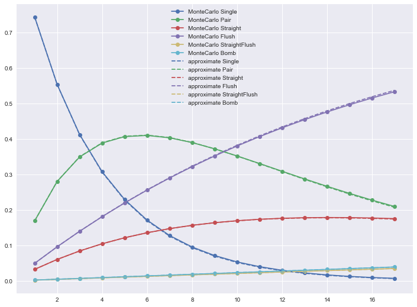

```python
plt.figure(figsize=(12, 9))
plot(np.arange(1, 18), fullList, '-o')
plot(np.arange(1, 18), apxFull, '--')
plt.legend(['MonteCarlo ' + n for n in TypeNames]
           + ['approximate ' + n for n in TypeNames]);
```

如上图，和蒙特卡罗方法的解非常接近  
误差变化如下：

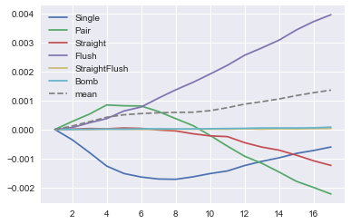

```python
plot(np.arange(1, 18), apxFull - fullList)

plot(
    np.arange(1, 18),
    np.abs(apxFull - fullList).mean(axis=1),
    '--',
    color='gray')
plt.legend(TypeNames + ['mean']);
```

总体上人数越多，误差越大

```python
trueRate_2 - apxFull[1]
```

```
matrix([[  3.5314e-04,  -2.7443e-04,  -1.1849e-05,  -6.5959e-05,
          -3.0842e-07,  -5.9378e-07]])
```

二人局的近似计算值与真值相差很小，而且越大的牌相差越小，因为此时条件概率中的条件更易达成，影响更小

## 总结

### 概率

每种类型的牌全场最大的概率随人数的变化曲线：

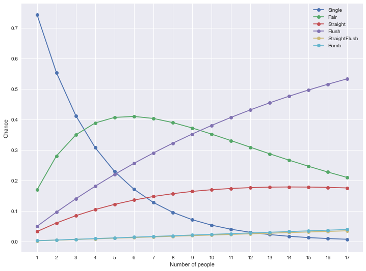

```python
plt.figure(figsize=(12, 9))
plot(np.arange(1, 18), fullList, '-o')
plt.legend(TypeNames)
plt.xticks(range(1, 18))
plt.xlabel('Number of people')
plt.ylabel('Chance');
```

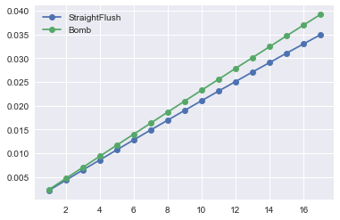

```python
plot(np.arange(1, 18), fullList[:, -2:], '-o')
plt.legend(TypeNames[-2:]);
```

绘制累加后的条形图：

```python
cuFull=fullList.cumsum(axis=1)
```

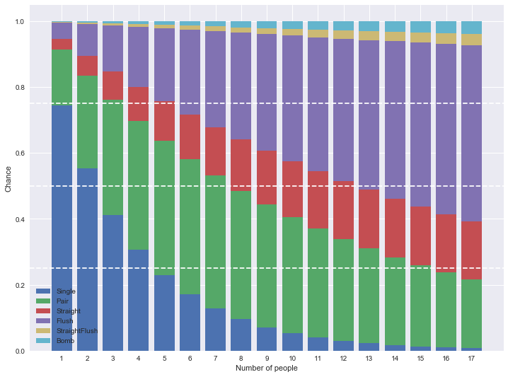

```python
plt.figure(figsize=(12, 9))
plt.bar(np.arange(1, 18), fullList[:, 0])
for i in range(1, 6):
    plt.bar(np.arange(1, 18), fullList[:, i], bottom=cuFull[:, i - 1])

plt.legend(TypeNames)
plt.axhline(0.5, linestyle='--', color='w')
plt.axhline(0.25, linestyle='--', color='w')
plt.axhline(0.75, linestyle='--', color='w')
plt.xticks(range(1, 18))
plt.xlabel('Number of people')
plt.ylabel('Chance');
```

例如8人局的时候，你拿到一副小顺子，此时有一半可能场上有比你大的牌

### 方法

|  | 穷举法 | 蒙特卡罗法 | 近似计算 |
| --- | --- | --- | --- |
| 复杂度 | 指数 随人数 | $O(n^2)$ 随精度 | $O(log(n))$ 随人数 |
| 速度 | 非常慢 | 可控 | 非常快 |
| 精度 | 无误差 | 可控 | 不可估 |
| 总评 | 不现实 | 可接受 | 可接受 |